# HW8_B66043

Dzvezdana Arsovska

April, 12 2017

## Homework 7 (Missed Practical Session)

I did not have any bigger issues with this assignment (except that the way in which the score was assigned in exercise 3 was a little bit confusing in the beginning). I made a mistake in the bonus task and I realized that after the submission.

Because I think that I understood the things correctly it is confusing for me how I lost so many points especially in exercise 4.

In this exercise I created new columns (predictions) by varying the threshold (the ROC score). For example everything that was above 0.2 was classified as TRUE, and everything bellow as FALSE. I looped through all the possible values of the threshold. Then I counted the number of TP, TN, FP and FN. I multiplied the type 1 and type 2 errors with the prices and I found the thresholds for which we have the minimal values.

So the part that is confusing for me here what else I needed to do.

Use the following data in next three tasks and predict the “play” column.

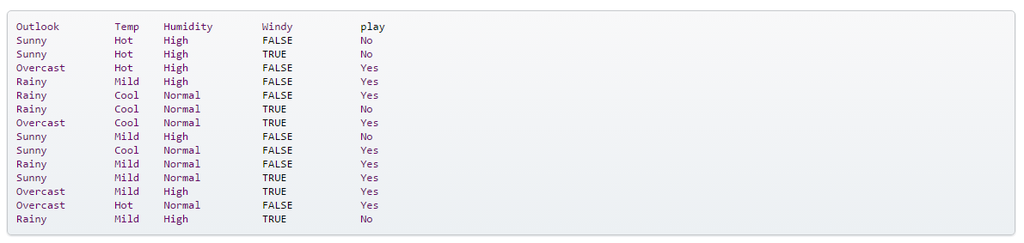

And classify this example by manual simulation of three following algorithms:

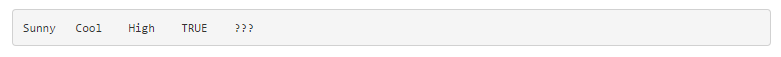

## Exercise 1

Build a decision tree simulating ID3 with Information Gain. Classify the example.

**Solution:**

One of the algorithms for building decision trees is ID3, which uses Entropy and Information Gain to construct a decision tree. Entropy is used to calculate the homogeneity of a sample. If the sample is completely homogeneous the entropy is zero and if the sample is an equally divided it has entropy of one. The information gain is based on the decrease in entropy after a data set is split on an attribute. When we are constructing a decision tree we are finding attribute that returns the highest information gain (i.e., the most homogeneous branches).

The ID3 steps are:

1. If the data set is pure, then construct a leaf having the name of the class.

else

2. Choose the feature with the highest information gain (In the beginning the gain is Gain(S,Outlook) = 0.246; Gain(S, Temperature) = 0.029; Gain(S, Humidity) = 0.151; Gain(S, Wind) = 0.048); so the root node is Outlook). Since Temperature has very low information gain we can expect that it will not be included in the final tree.
3. For each value of that feature:
- take the subset of the data-set having that feature value
- construct a child node having the name of that feature value
- call the algorithm recursively on the child node and the subset

For creating data frames and node like objects used for visualizing the tree the data.table and data.tree libraries are used.

```r
# Check if one of the features is completly pure
PureNode <- function(data) {
    length(unique(data[, ncol(data)])) == 1
}

# Calculate the entropy
Entropy <- function(S) {
    res <- S/sum(S) * log2(S/sum(S))
    res[S == 0] <- 0
    -sum(res)
}

# Calculate the information gain
Information_Gain <- function(feat) {
    entropyBefore <- Entropy(colSums(feat))
    s <- rowSums(feat)
    entropyAfter <- sum(s/sum(s) * apply(feat, MARGIN = 1, FUN = Entropy))
    Information_Gain <- entropyBefore - entropyAfter
    return(Information_Gain)
}

TrainID3 <- function(node, data) {

    node$obsCount <- nrow(data)

    # if the data set is pure then create a leaf with the name of the pure
    # feature if the data set is completly pure stop
    if (PureNode(data)) {
        child <- node$AddChild(unique(data[, ncol(data)]))
        node$feature <- tail(names(data), 1)
        child$obsCount <- nrow(data)
        child$feature <- ""
    } else {
        # if the data set is not pure calculate the information gain
        ig <- sapply(colnames(data)[-ncol(data)], function(x) Information_Gain(table(data[,
            x], data[, ncol(data)])))

        # chose the feature with the highest information gain if more than one
        # feature have the same information gain, then take the first one
        feature <- names(which.max(ig))
        node$feature <- feature

        childObs <- split(data[, names(data) != feature, drop = FALSE], data[,
            feature], drop = TRUE)

        for (i in 1:length(childObs)) {
            # construct a child
            child <- node$AddChild(names(childObs)[i])

            # call the algorithm recursively
            TrainID3(child, childObs[[i]])
        }
    }
}

# Build the tree using the train data and print it
tree <- Node$new("train_data")
TrainID3(tree, train_data)
print(tree, "feature")
```

```
##          levelName  feature
## 1  train_data       Outlook
## 2   ¦--Sunny       Humidity
## 3   ¦   ¦--High        Play
## 4   ¦   ¦   °--No
## 5   ¦   °--Normal      Play
## 6   ¦       °--Yes
## 7   ¦--Rainy          Windy
## 8   ¦   ¦--Strong      Play
## 9   ¦   ¦   °--No
## 10  ¦   °--Weak        Play
## 11  ¦       °--Yes
## 12  °--Overcast        Play
## 13      °--Yes
```

```r
# Prediction
Predict <- function(tree, features) {
    if (tree$children[[1]]$isLeaf)
        return(tree$children[[1]]$name)
    child <- tree$children[[features[[tree$feature]]]]
    return(Predict(child, features))
}

# Call the predict function for the test data set
Predict(tree, c(Outlook = "Sunny", Temperature = "Cool", Humidity = "High",
    Windy = "Strong"))
```

```
## [1] "No"
```

The example is classified as Play = **No**.

The set of rules generated by the tree are:

- **Rule1**: IF (Outlook = Sunny) AND (Humidity = High) THEN (Play = No)
- **Rule2**: IF (Outlook = Sunny) AND (Humidity = Normal) THEN (Play = Yes)
- **Rule3**: IF (Outlook = Overcast) THEN (Play = Yes)
- **Rule4**: IF (Outlook = Rain) AND (Wind = Strong) THEN (Play = No)
- **Rule5**: IF (Outlook = Rain) AND (Wind = Weak) THEN (Play = Yes)

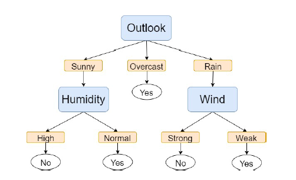

## Exercise 2

Build a Naive Bayes classifier. Classify the example.

**Solution:**

Naive Bayes Classifier is a classifiers which assumes that all features are statistically independent of one another. Unlike many other classifiers which assume that, for a given class, there will be some correlation between features, naive Bayes explicitly models the features as conditionally independent given the class.

Using the 4 attributes we need to create conditional probability tables. We also need to note that the A-priori probabilities are: $P(YES) = 9/14$ and $P(NO) = 5/14$.

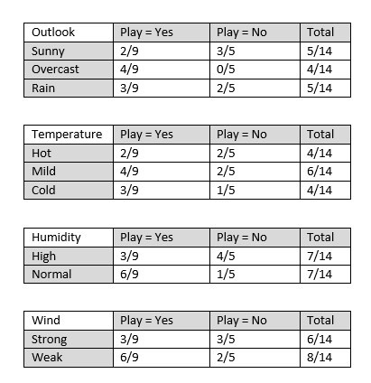

The probabilities for the unseen example are:

$\frac{P(YES) P(Sunny|YES) P(Cool|YES) P(Humidity|HIGH) P(Wind|STRONG)}{P(Sunny) P(Cool) P(High) P(Strong)} = \frac{0.64*0.22*0.33*0.33*0.33}{0.3571*0.2857*0.5*0.4285} = \frac{0.0052}{0.02186} = 0.2424$

$\frac{P(NO) P(Sunny|NO) P(Cool|NO) P(Humidity|NO) P(Wind|NO)}{P(Sunny) P(Cool) P(High) P(Strong)} = \frac{0.3571429*0.6*0.2*0.8*0.6}{0.02186} = \frac{0.0205}{0.02186} = 0.9421$

From this values we can conclude that the classification is **No**.

The probability tables can be calculated in R using the following function. After getting the probabilities we just need to multiply them in a same way as above in order to determine the classification.

```r
# Bayess classifier

tbl_list <- sapply(train_data[-ncol(train_data)], table, train_data[, ncol(train_data)])
tbl_list <- lapply(tbl_list, t)

cond_probs <- sapply(tbl_list, function(x) {
    apply(x, 1, function(x) {
        x/sum(x)
    })
})

cond_probs <- lapply(cond_probs, t)

print(cond_probs)
```

```
## $Outlook
##
##           Sunny     Rainy  Overcast
##   Yes 0.2222222 0.3333333 0.4444444
##   No  0.6000000 0.4000000 0.0000000
##
## $Temperature
##
##             Hot      Mild      Cool
##   Yes 0.2222222 0.4444444 0.3333333
##   No  0.4000000 0.4000000 0.2000000
##
## $Humidity
##
##            High    Normal
##   Yes 0.3333333 0.6666667
##   No  0.8000000 0.2000000
##
## $Windy
##
##          Strong      Weak
##   Yes 0.3333333 0.6666667
##   No  0.6000000 0.4000000
```

We can check the result using the built in function. And we can see that the results match.

```r
# Just for check, built in Bayess classifier

model <- naiveBayes(Play ~ ., train_data)

print(model)
```

```
##
## Naive Bayes Classifier for Discrete Predictors
##
## Call:
## naiveBayes.default(x = X, y = Y, laplace = laplace)
##
## A-priori probabilities:
## Y
##       Yes        No
## 0.6428571 0.3571429
##
## Conditional probabilities:
##      Outlook
## Y         Sunny     Rainy  Overcast
##   Yes 0.2222222 0.3333333 0.4444444
##   No  0.6000000 0.4000000 0.0000000
##
##      Temperature
## Y           Hot      Mild      Cool
##   Yes 0.2222222 0.4444444 0.3333333
##   No  0.4000000 0.4000000 0.2000000
##
##      Humidity
## Y          High    Normal
##   Yes 0.3333333 0.6666667
##   No  0.8000000 0.2000000
##
##      Windy
## Y        Strong      Weak
##   Yes 0.3333333 0.6666667
##   No  0.6000000 0.4000000
```

```r
preds <- predict(model, test)
preds
```

```
## [1] No
## Levels: Yes No
```

## Exercise 3

Classify the example using k-nearest neighbor method. Use 1-nn, 3-nn, and 5-nn method. For distance measure you can for example count how many variables differ (Manhattan distance); possibly making ordinal values like hot-cool differ by “distance” (e.g. hot-cool=2, hot-mild=1).

**Solution:**

in order to compute knn first we need to rearrange the data set using dummy variables so it has the following form. For that purpose I used caret’s DummyVariable function.

```r
train_data
```

```
##    Play Sunny Overcast Rainy Hot Cool Mild High Normal Strong Weak
## 1    No     1        0     0   1    0    0    1      0      0    1
## 2    No     1        0     0   1    0    0    1      0      0    0
## 3   Yes     0        1     0   1    0    0    1      0      0    1
## 4   Yes     0        0     1   0    0    1    1      0      0    1
## 5   Yes     0        0     1   0    1    0    0      1      0    1
## 6    No     0        0     1   0    1    0    0      1      0    0
## 7   Yes     0        1     0   0    1    0    0      1      0    0
## 8    No     1        0     0   0    0    1    1      0      0    1
## 9   Yes     1        0     0   0    1    0    0      1      0    1
## 10  Yes     0        0     1   0    0    1    0      1      0    1
## 11  Yes     1        0     0   0    0    1    0      1      0    0
## 12  Yes     0        1     0   0    0    1    1      0      0    0
## 13  Yes     0        1     0   1    0    0    0      1      0    1
## 14   No     0        0     1   0    0    1    1      0      0    0
```

K nearest neighbors is an algorithm that stores all available cases and classifies new cases based on a similarity measure (e.g., distance functions). A case is classified by a majority vote of its neighbors, with the case being assigned to the class most common among its K nearest neighbors measured by a distance function. If K = 1, then the case is simply assigned to the class of its nearest neighbor.

Using the following code we can calculate the similarity between the test and the train data using Euclidean distance.

```r
for (i in 1:nrow(train_data)) {
    sim = sqrt(((train_data[, 2] - 1)^2) + ((train_data[, 3] - 0)^2) + ((train_data[,
        4] - 0)^2) + ((train_data[, 5] - 0)^2) + ((train_data[, 6] - 1)^2) +
        ((train_data[, 7] - 0)^2) + ((train_data[, 8] - 1)^2) + ((train_data[,
        9] - 0)^2) + ((train_data[, 10] - 1)^2) + ((train_data[, 11] - 0)^2))
    train_data$sim = sim
}

# sort the distances
X <- train_data[order(sim), ]

X
```

```
##    Play Sunny Overcast Rainy Hot Cool Mild High Normal Strong Weak
## 2    No     1        0     0   1    0    0    1      0      0    0
## 1    No     1        0     0   1    0    0    1      0      0    1
## 8    No     1        0     0   0    0    1    1      0      0    1
## 9   Yes     1        0     0   0    1    0    0      1      0    1
## 6    No     0        0     1   0    1    0    0      1      0    0
## 7   Yes     0        1     0   0    1    0    0      1      0    0
## 11  Yes     1        0     0   0    0    1    0      1      0    0
## 12  Yes     0        1     0   0    0    1    1      0      0    0
## 14   No     0        0     1   0    0    1    1      0      0    0
## 3   Yes     0        1     0   1    0    0    1      0      0    1
## 4   Yes     0        0     1   0    0    1    1      0      0    1
## 5   Yes     0        0     1   0    1    0    0      1      0    1
## 10  Yes     0        0     1   0    0    1    0      1      0    1
## 13  Yes     0        1     0   1    0    0    0      1      0    1
##         sim
## 2  1.732051
## 1  2.000000
## 8  2.000000
## 9  2.000000
## 6  2.236068
## 7  2.236068
## 11 2.236068
## 12 2.236068
## 14 2.236068
## 3  2.449490
## 4  2.449490
## 5  2.449490
## 10 2.828427
## 13 2.828427
```

When k = 1, the nearest neighbor has Euclidean distance of 1.732 and the classification is **No**.

When k = 3, the nearest distances are 1.732 (No), 2 (No) and 2 (No) and the classification is **No**.

When k = 5, the nearest distances are 1.732 (No), 2 (No), 2 (No), 2 (Yes), 2.236 (No) and by majority voting the classification is **No**.

When can check the results using the built in function in R.

```r
knn(select(train_data, Outlook, Temperature, Humidity, Windy), select(test,
    Outlook, Temperature, Humidity, Windy), train_data$Play, k = 1)
```

```
## [1] No
## Levels: Yes No
```

```r
knn(select(train_data, Outlook, Temperature, Humidity, Windy), select(test,
    Outlook, Temperature, Humidity, Windy), train_data$Play, k = 3)
```

```
## [1] No
## Levels: Yes No
```

```r
knn(select(train_data, Outlook, Temperature, Humidity, Windy), select(test,
    Outlook, Temperature, Humidity, Windy), train_data$Play, k = 5)
```

```
## [1] No
## Levels: Yes No
```

## Exercise 4

Use the data set “Bank Marketing”. Apply decision tree and Naive Bayes classifier on this data. Perform 5-fold cross validation (withhold 20% of data each time) and report the goodness of the built classifiers.

**Solution**:

- Decision tree

The bank data set has 17 columns and y is the target variable (which has significantly higher number of no values). For building the decision tree I will use the RWeka package and the J48 function which generates C4.5 decision tree. Before running the function we need to convert some of the variables to factors.

Then we can split the data in train and test set.

```r
set.seed(2)

bound <- floor((nrow(X)/4) * 3.2)  # 80% training set, 20% test test

df <- X[sample(nrow(X)), ]  # sample random rows
df.train <- X[1:bound, ]  # get training set
df.test <- X[(bound + 1):nrow(X), ]  # get test set
```

And create the decision tree for predicting the target variable y.

```r
m1 <- J48(y ~ ., data = df.train)
summary(m1)
```

```
##
## === Summary ===
##
## Correctly Classified Instances       31921               96.4556 %
## Incorrectly Classified Instances      1173                3.5444 %
## Kappa statistic                          0.669
## Mean absolute error                      0.0564
## Root mean squared error                  0.1679
## Relative absolute error                 45.9071 %
## Root relative squared error             67.761  %
## Total Number of Instances            33094
##
## === Confusion Matrix ===
##
##      a     b   <-- classified as
##  30632   288 |     a = no
##    885  1289 |     b = yes
```

```r
gain <- information.gain(y ~ ., data = df.train)
gain
```

```
##           attr_importance
## age          0.0016519992
## job          0.0004083294
## marital      0.0012481648
## education    0.0007557131
## default      0.0000000000
## balance      0.0012404988
## housing      0.0013800092
## loan         0.0004702622
## contact      0.0037235470
## day          0.0029694724
## month        0.0118832355
## duration     0.0748911585
## campaign     0.0003856322
## pdays        0.0000000000
## previous     0.0000000000
## poutcome     0.0000000000
```

```r
a <- predict(m1, df.test[, 1:16])
df.test$new <- a

true_pos <- which(df.test[, 17] == "yes" & df.test[, 18] == "yes")
true_neg <- which(df.test[, 17] == "no" & df.test[, 18] == "no")
type1 <- which(df.test[, 17] == "no" & df.test[, 18] == "yes")
type2 <- which(df.test[, 17] == "yes" & df.test[, 18] == "no")
length(true_pos)
```

```
## [1] 702
```

```r
length(true_neg)
```

```
## [1] 5212
```

```r
length(type1)
```

```
## [1] 650
```

```r
length(type2)
```

```
## [1] 1710
```

We ca notice that we have a high number of FN.

- Naive Bayes Classification

```r
model <- naiveBayes(y ~ ., df.train)
# print(model)
preds <- predict(model, df.test)
df.test$new <- preds

true_posb <- which(df.test[, 17] == "yes" & df.test[, 18] == "yes")
true_negb <- which(df.test[, 17] == "no" & df.test[, 18] == "no")
type1b <- which(df.test[, 17] == "no" & df.test[, 18] == "yes")
type2b <- which(df.test[, 17] == "yes" & df.test[, 18] == "no")
length(true_posb)
```

```
## [1] 279
```

```r
length(true_negb)
```

```
## [1] 5734
```

```r
length(type1b)
```

```
## [1] 128
```

```r
length(type2b)
```

```
## [1] 2133
```

We can notice that again we have a high number of FN.

- Cross Validation

When we are using K-fold cross validation method the data set is divided into k subsets, and each time, one of the k subsets is used as the test set and the other k-1 subsets are put together to form a training set. Then the average error across all k trials is computed.

For calculating the 5 fold cross validation I used the following function (I am not calling the function because in that case it takes a lot of time to knit the RMarkdown. Therefore I will just report the results).

```r
# 5 fold cross validation

# Randomly sample the data
X <- X[sample(nrow(X)), ]

# Create 5 equally size folds
folds <- cut(seq(1, nrow(X)), breaks = 5, labels = FALSE)

# Perform 5 fold cross validation
for (i in 1:5) {
    # Segement your data by fold using the which() function
    testIndexes <- which(folds == i, arr.ind = TRUE)
    testData <- X[testIndexes, ]
    trainData <- X[-testIndexes, ]
    model <- J48(y ~ ., data = trainData)  # Replace after with Naive Bayess and Random Forest
    summary(model)
    a <- predict(model, testData[, 1:16])
}
```

**The calculated accuracy (averaged over the splits) for the decision tree is 89% and for the Naive Bayess classificator 86%, which was expected since we calculated previously that we have bigger number of FN during the Naive Bayess classification.**

Also, using the caret library we can calculate the cross validation using the built in train function.

```r
# Example of 5 fold cross validation using the built in train function

fit <- train(y ~ ., X, method = "J48", trControl = trainControl(method = "cv",
    number = 5, verboseIter = TRUE))
```

## Exercise 5

Apply the Random Forest method on the same data set. Report the quality similar as in 4. Draw an ROC curve for RF classifier. What is the basis of scoring and ordering the predictions in order to achieve the ROC curve?

**Solution:**

Random forest is an ensemble learning method that operates by constructing a multitude of decision trees at training time and outputting the class that is the mode of the classes (classification) or mean prediction (regression) of the individual trees. In R we can use the library randomForest.

```r
# Check for unique values apply(X,2,function(x) length(unique(x)))

set.seed(42)
rownames(X) <- 1:nrow(X)
rows <- sample(x = 1:nrow(X), size = 0.7 * nrow(X))

trainDF <- X[rows, ]
testDF <- X[!rownames(X) %in% rows, ]
```

One of the arguments used in the creation of random trees is mtry which gives the number of variables randomly sampled as candidates at each split. We can find the optimal value using the tuneRF function.

```r
# Find optimal mtry

# bestmtry <- tuneRF(trainDF,trainDF$y,ntreeTry = 200,nodesize =
# 40,stepFactor = 1.2,improve = 0.01, trace=T,plot=T)

# High strength of tree = Low error rate of individual tree classifier

model0 <- randomForest(y ~ ., data = trainDF, mtry = 6, nodesize = 30, ntree = 200,
    type = regression)

model1 <- update(model0, . ~ . - default)
model2 <- update(model1, . ~ . - loan)
model3 <- update(model2, . ~ . - marital)

importance(model3)
```

```
##           MeanDecreaseGini
## age              245.53230
## job              223.58850
## education         52.17054
## balance          222.44501
## housing           72.75962
## contact           79.10591
## day              211.17141
## month            583.25470
## duration        1444.35372
## campaign          64.36166
## pdays            158.93123
## previous          47.28149
## poutcome         509.32392
```

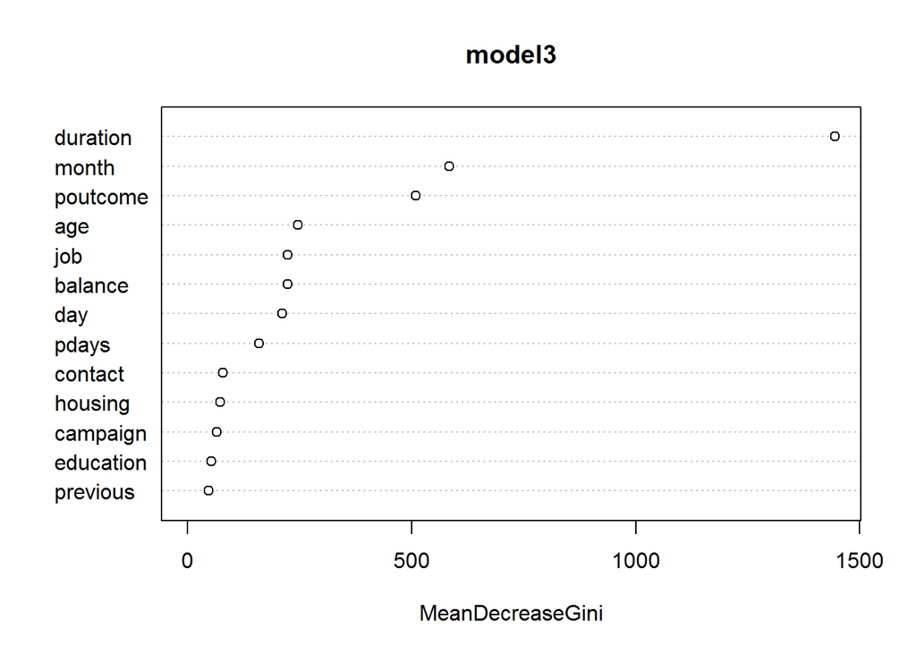

```r
varImpPlot(model3)
```

```r
# Predict the y value of the test data
pred <- predict(model3, testDF, type = "response")
testDF$pred <- pred


true_posb <- which(testDF[, 17] == "yes" & testDF[, 18] == "yes")
true_negb <- which(testDF[, 17] == "no" & testDF[, 18] == "no")
type1b <- which(testDF[, 17] == "no" & testDF[, 18] == "yes")
type2b <- which(testDF[, 17] == "yes" & testDF[, 18] == "no")
length(true_posb)
```

```
## [1] 755
```

```r
length(true_negb)
```

```
## [1] 11532
```

```r
length(type1b)
```

```
## [1] 449
```

```r
length(type2b)
```

```
## [1] 828
```

```r
# Cross validation fit <- train(y ~. , X, method = 'rf', trControl =
# trainControl(method = 'cv', number = 5, verboseIter = TRUE))
```

We can notice that we are getting the best results using Random Forest and we can confirm this using cross validation. The accuracy for this model is 92%.

To plot the ROC curve for this classifier we need to sort the probabilities (the probability of detection (TPR) and the probability of false alarm (FPR)). For that purpose we can use the library ROCR which compares the predicted and the actual values and find the rate of the type 1 and type 2 errors. Using this information we can plot the ROC curve and calculate the AUC.

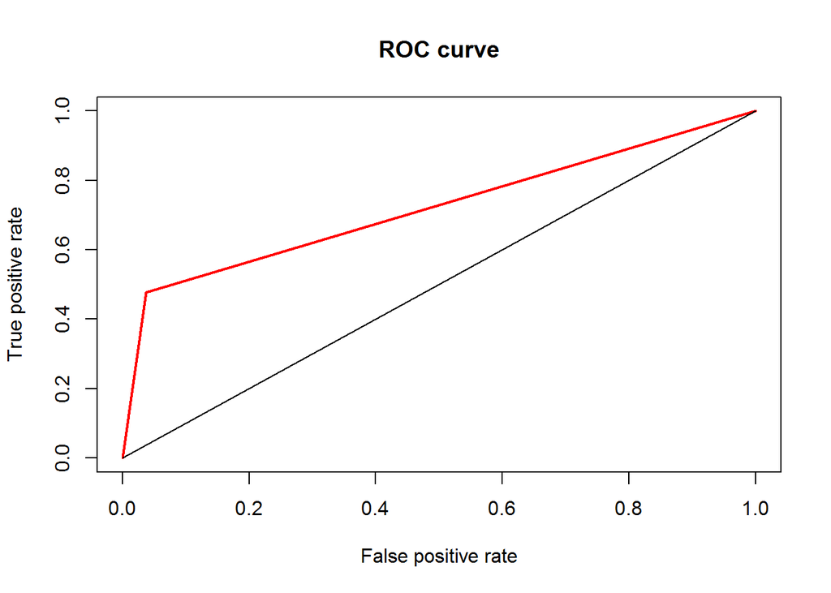

```r
# Plot the ROC curve
preds <- prediction(as.numeric(pred), testDF$y)
roc <- performance(preds, "tpr", "fpr")

plot(roc, lwd = 2, col = "red", main = "ROC curve")
lines(x = c(0, 1), y = c(0, 1), col = "black", lwd = 1)
```

```r
auc1 = performance(preds, "auc")
auc1 = unlist(auc1@y.values)
auc1
```

```
## [1] 0.7197333
```

## Exercise 6

Extract the most relevant features from the above Bank Marketing data based on inspection of random forest classifier, decision tree, and Naive Bayes. Justify and interpret these features.

**Solution:**

When we are using the **random forest** we can find the most important features using the following functions.

```r
importance(model3)
```

```
##           MeanDecreaseGini
## age              245.53230
## job              223.58850
## education         52.17054
## balance          222.44501
## housing           72.75962
## contact           79.10591
## day              211.17141
## month            583.25470
## duration        1444.35372
## campaign          64.36166
## pdays            158.93123
## previous          47.28149
## poutcome         509.32392
```

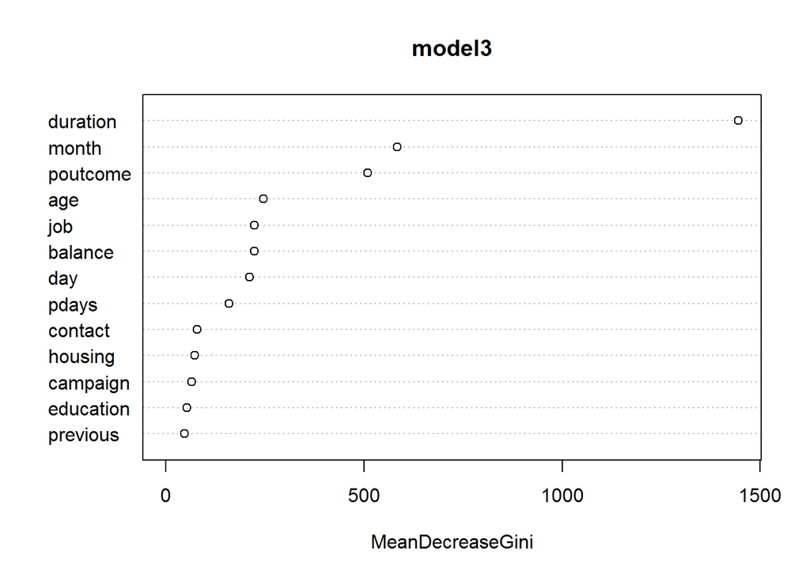

```r
varImpPlot(model3)
```

From the generated plot we can notice that **duration, month** and **poutcome** are the most important features. If we drop them from the model, it’s prediction power will greatly reduce. On the other hand if we reduce one of the bottom variables, there might not be much impact on prediction power of the model.The measure used for determining the feature importance is by calculating the node purity using the Gini index. The **Gini Index** which is the the difference between Residual sum of squares (RSS) before and after the split on that variable.

When we are using **decision trees** we are measuring the **information gain** and the most important features are the one that have the highest information gain. Using the library FSelector and the function information.gain we can get the information gain of each variable and determine their importance. I already calculated the most important features in exercise 4 and they are also **duration** and **month**.

Before creating random forest or a decision tree we can check if there are 2 highly correlated features using **cor(data)** and drop the ones that are highly correlated and do not improve the model.

When we are using **Naive Bayess classificator** it is best to select the features with the highest **Information gain** or the highest **Mutual information**. Another approach is using **PCA** . If we use the resulting principal component vectors as features, it is possible to select only those that explain the major variance in the data set. With this method you actually still have to inject all features to your method but Naive Bayes has less feature to deal with and, consequently, gives better probability estimates.

For this case the 2 best features in the Naive Bayess are **duration** and **month**.

We can use the caret’s recursive feature selection for finding the best features. In the plot we can see how the accuracy rises or drops when a certain feature is added to the model.

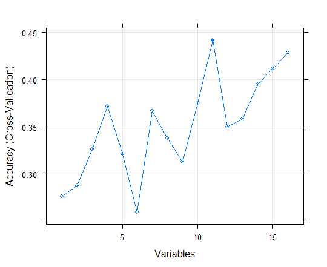

```r
control <- rfeControl(functions = rfFuncs, method = "cv", number = 5)
# run the RFE algorithm
results <- rfe(X[, 1:16], X[, 17], sizes = c(1:16), rfeControl = control)
plot(results)
```